# Remote Resources

MIT Political Science Methodology Lab (PML) Workshop Series

Mason Reece

Gabrielle Péloquin-Skulski

October 18, 2024

## Goals

- Hands on experience!
- `xvii`
- Supercloud
- When to Use What

## Resource Comparison

XVII – Learning, long-term scraping tasks

Supercloud – Parallellized scripts, large memory requirements, etc.

## Setting up XVII

We’ll make you an account

Connecting to xvii via `ssh` – Mac/Linux use the *Terminal*, Windows use *Powershell*

```bash
ssh <your username>@xvii.mit.edu
```

*Immediately change your password using `passwd`* *and save it somewhere*

## Basic Linux Commands

```bash
ls                      # List files
pwd                     # Print working directory
cd <to>                 # Change directory
mv <file> <from> <to>   # Move files
mkdir <name of dir>     # Create new directory
nano <file>             # Command line text editor
cat <file>              # Print contents of file
rm -rf <dir or file>    # Delete stuff (no undo!)
find                    # Finding files/folders
rsync <from> <to>       # Transfer data
passwd                  # Change your password
```

## Important xvii Commands

- `htop` to check CPU/RAM usage of server
- `ps aux | grep <username>` Prints out all the processes you have running. Useful for killing processes that have stalled or have other issues
- `kill -i <pid>` Kills a process you have running. `<pid>` comes from the previous command

## RStudio on the Web

- Go to [http://xvii.mit.edu:8787](https://xvii.mit.edu:8787)
- Login with your username and password
  - Clear your cookies if you can’t connect
- Just like regular RStudio but runs on XVII
  - Occasionally it hangs/breaks, contact the PML RA to fix this

## Performance – Laptop vs xvii

```r
# install.packages(c("tidyverse", "palmerpenguins", "tictoc"))

# Load the palmerpenguins dataset
data("penguins", package = "palmerpenguins")

tictoc::tic()

# Simulate heavy computational work (Single Core)
result <- purrr::map(1:100000, ~ {
    penguins |>
      dplyr::filter(species == "Adelie") |>
      dplyr::pull(bill_length_mm) |>
      mean()
  })

tictoc::toc()
```

```
41.337 sec elapsed
```

xvii took 165.294 seconds (whoops)

## Parallel Processing on xvii

```r
# install.packages("furrr")

# Load the palmerpenguins dataset
data("penguins", package = "palmerpenguins")

library(furrr)

tictoc::tic()

plan(multisession, workers = 8)

# Simulate heavy computational work (MultiCore)
result <- furrr::future_map(1:100000, ~ {
    penguins |>
      dplyr::filter(species == "Adelie") |>
      dplyr::pull(bill_length_mm) |>
      mean()
  })

plan(sequential)

tictoc::toc()
```

XVII took 25.883 seconds (a 6.3x speedup)

## Notes on XVII

[figure not shown]

- Powerful, but remember this is a shared resource among the department

## Uploading Big Data or Scripts

- Use Filezilla: https://filezilla-project.org/download.php?type=client or `rsync`
- *MUST* store your data in **`/mnt/xvii_big_data/<username>/`**
- Code can go in `/home/<username>`
  - If your big data goes here and fills up the drive, xvii won’t work
- How to connect to xvii using FTP program
  - Host: `xvii.mit.edu`
  - Username: `<your username>`
  - Password: `<your password>`
  - Port: `22`

## Do You Need More High-Performance Computing?

- [MIT SuperCloud](https://supercloud.mit.edu/getting-started)
  - Loads more computing power (basically your own xvii + more)
  - Requires special advisor approval + edx course
  - More difficult to use

## Resource Limits

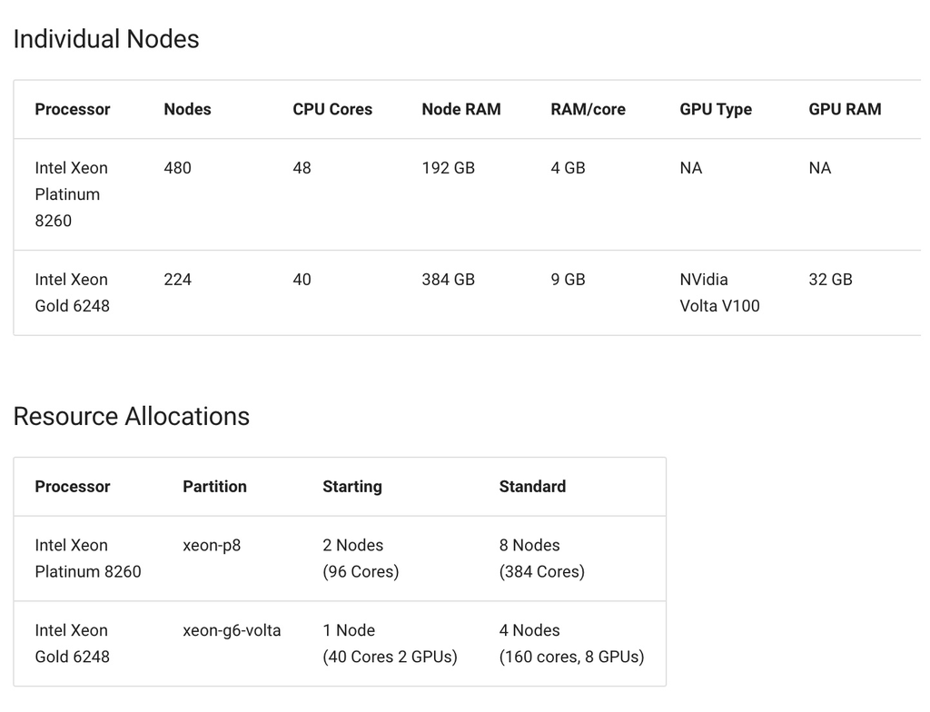

- Time Limits: Jobs are limited to 4 days and 4 hours
  - *Tip*: If your task doesn’t complete within this timeframe, your code may need optimization—consider attending a **PLM workshop** for help.
- Only accessible WITHIN the US (I have been able to use it in Canada with a VPN)

## Advantages of SuperCloud as Opposed to XVII

- **Increased power:** Access to more computational resources, including thousands of CPU cores and GPUs.
- **Up-to-date environment:** Fewer issues with outdated packages or software compatibility.
- **Support resources:** Available office hours for personalized help, along with extensive online documentation and tutorials.

**Disadvantage:** - **No RStudio interface:** Unlike XVII, SuperCloud doesn’t provide a direct RStudio interface for running analyses, requiring users to manage R from the command line

## Getting Access to SuperCloud

1. Complete a cybersecurity training before applying for a SuperCloud account (very short).
   - [MIT SANS IT Security Awareness I](https://atlas.mit.edu/atlas/Main.action?tab=home&sub=group_training&urlParameters=base%3Dlearner%26anchor%3D%2Fcourse-catalog%2FCSS00030w) & [IT Security Awareness II](https://atlas.mit.edu/atlas/Main.action?tab=home&sub=group_training&urlParameters=base%3Dlearner%26anchor%3D%2Fcourse-catalog%2FCSS00031w) OR the [Cybersecurity Awareness Challenge](https://public.cyber.mil/training/cyber-awareness-challenge/)
2. Fill out the [account request form](https://txe1-portal.mit.edu/login/request.php).
3. Request approval from your advisor/PI by having them email supercloud@mit.edu to confirm that you will be using SuperCloud for your work. *Note*: SuperCloud will not contact your advisor directly—you must handle this step to get approval.
- *Note* that approval can take up to a week.

## Setting Up Your Account

- Once you get approval you will receive an email with your username and further instructions to set up your account
- You will be working only on the terminal of your computer

## Setting Up Your Account (cont.)

1. Create Key

```bash
[user1234@yourMachine]$ ssh-keygen -t rsa
```

- *See also*: [https://supercloud.mit.edu/requesting-account](https://supercloud.mit.edu/requesting-account#ssh-keys)
2. Copy generated key

```bash
cat id_rsa.pub
```

- Copy the entire output, including the ssh-rsa at the beginning.
3. Add key to your account
- Go to: https://txe1-portal.mit.edu/
- Use the touchstone
- Click on sshkeys, and then add new key. Paste the key from terminal.

## Setting Up R and Your Packages

- To set up R and add packages you need to [create a Conda environment](https://supercloud.mit.edu/software-and-package-management/)
1. Log in

```bash
ssh username@txe1-login.mit.edu
```

2. Load anaconda module

```bash
source /etc/profile
module load anaconda/2023b
conda create -n customR -c conda-forge r-essentials r-tidyverse r-brms
```

3. Create custom conda environment

```bash
source activate customR
R
install.packages(c(“tidyverse”, “brms”) # sample packages
```

## Upload Your Files

1. Open new console tab, where you are NOT logged in to the MIT account.
2. Add your files to your SuperCloud account. *Note*: First part of the code is where the file is located on computer and second part is where you want the file to be located on SuperCloud

```bash
rsync ~ /Desktop/file.R username@txe1-login.mit.edu:/home/gridsan/username
```

3. Check if files successfully uploaded to your SuperCloud account.

```bash
ssh username@txe1-login.mit.edu # Login to SuperCloud Account
ls
```

## Submit Your Job

1. Create a shell that will run your script

```bash
nano yourNewScript.sh
```

2. Edit your shell and write the following text in it.

```bash
#!/bin/bash

source /etc/profile

# Load the required modules
module load anaconda/2023b
source activate customR

# Run the script
Rscript ~/your_rscript.R
```

3. `Ctrl + X` to leave the shell

## Submit Your Job (Cont.)

```bash
LLsub yourNewScript.sh -s 25
```

## Checking on Job Status

1. See Running Jobs (*Note*: This gives us the `jobid` which we plug into the scheduler)

```bash
LLstat
```

2. See status of job (*Note*: 24167762 in this example is my `jobid`)

```bash
cat yourNewScript.sh.log-24167762
```

## Exporting Files to Your Computer

1. Create new blank tab in terminal where you are not logged into SuperCloud.
2. Export files (just flip order of how you imported the files)

```bash
rsync username@txe1-login.mit.edu:/home/gridsan/username/file_output.rds ~ /Desktop
```

## Other Notes

- SuperCloud has monthly downtimes: every second Tuesday of each month. Reminder emails are sent out in advance and when the downtime is complete.
- The SuperCloud team offers weekly office hours (announced via email)
- For more help email: supercloud@mit.edu or see their online [resources](https://mit-supercloud.github.io/supercloud-docs/)
- You can upgrade your resource allocation by completing the [Practical HPC](https://learn.llx.edly.io/course/practical-hpc/) course with a grade higher than 70%

# Thank You!

## Appendix

## Running Your Script in Shell

Useful if code is slow, you have to leave your computer, etc.

```bash
Rscript <path-to-script>    # For R, capitalization matters
python <path-to-script>     # For python
```

Trick for slow code:

- Use a bash script and make it run in the background

  ```bash
  nohup bash scheduler.sh &
  ```

- where `scheduler.sh` is:

  ```bash
  /usr/lib/R/bin/R –no-restore –file=<path-to-file>
  ```

- Same as Rscript, but printed output goes to a plain-text file called `nohup.out` and it runs forever
- Check in with `htop` (always works) or `jobs` (works sporadically)

## For Python Users

Install Anaconda in `/home/username` , xvii only has Python 2.7

How to Use Jupyter Notebooks:

- Use port forwarding to send the Jupyter notebook to a localhost. DO NOT SSH into xvii before doing this

  ```bash
  ssh -N -f -L 8000:localhost:8888 <your username>@xvii.mit.edu
  ```

- Then, ssh into XVII and start Jupyter:

  ```bash
  jupyter notebook --no-browser --port=8888
  ```

- Then, connect on the internet at the URL: `localhost:8000` and enter the code given when you started jupyter. There may be no code.

Remote Resources